# R俱乐部

## day04

### 杜 月新

### RStudio

### 2020/11/02

##day04 ggplot2的运用

install.packages("tidyverse")

# 准备

```r
 library(tidyverse)
```

## plot与ggplot

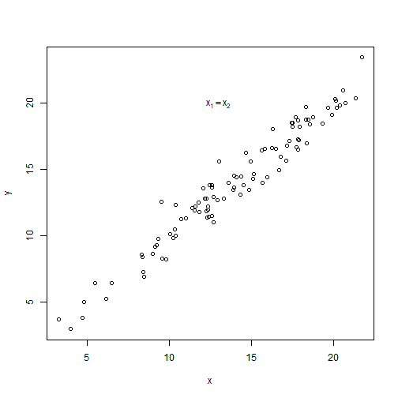

```r
#plot画图
x <- rnorm(100,14,5)
y <- x + rnorm(100,0,1)
plot(x,y)
text(13,20, expression(x[1] == x[2]))
```

# 比较

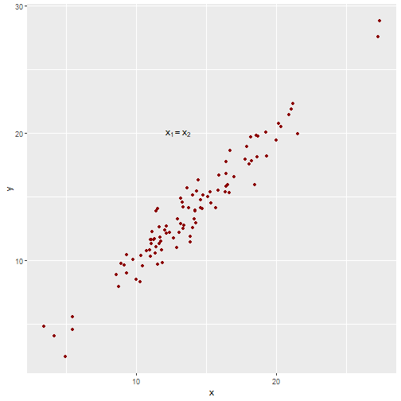

```r
# ggplot画图
x <- rnorm(100,14,5)
y <- x + rnorm(100,0,1)
ggplot(data= NULL, aes(x = x, y = y)) +         #开始绘图
  geom_point(color = "darkred") +               #添加点
  annotate("text",x =13 , y = 20,parse = T,
           label = "x[1] == x[2]")              #添加注释
```

- plot:绘图方式实际上是按照命令添加的，以plot开始，可以以任何方式结束，每加上一个元素，实际上都是以一句单独的命令来实现。
但是这样的图片第一没有完整性，第二不够美观。
- ggplot：1.有明确的开始（以ggplot函数为开始）与终止（一句语句一幅图）；2.图层之间的叠加是靠“+”号实现的，越后面其图层越高。

>关于ggplot2
- ggplot2的核心理念是将绘图与数据分离，数据相关的绘图与数据无关的绘图分离，是按
图层作图，有利于结构化思维，同时它保有命令式作图的调整函数，使其更具灵活性，绘制出来的图形美观，同时避免繁琐细节。
- 大致分位三个部分：
 - 数据层
 - 几何图形层
 - 视觉感受

# 关于ggplot2

-大致以下包含了以下几个基本概念：
 - 数据（Data）和映射（Mapping）：将数据中的变量映射到图形属性。映射控制了二者之间的关系。
 - 标度（Scale）：标度负责控制映射后图形属性的显示方式。具体形式上来看是图例和坐标刻度。Scale和Mapping是紧密相关的概念。
 - 几何对象（Geometric）：几何对象代表我们在图中实际看到的图形元素，如点、线、正方块等多边形。
 -  统计变换（Statistics）：对原始数据进行某种统计计算，例如对二元散点图加上一条回归线或者置信区间登记。
 - 图层（Layer）
 - 分面（Facet）：条件绘图，将数据按某种方式分组，然后分别绘图。分面就是控制分组绘图的方法和排列形式。

# 画图（data：mpg）

```r
mpg
```

```
## # A tibble: 234 x 11
##    manufacturer model displ  year   cyl trans drv     cty   hwy
##    <chr>        <chr> <dbl> <int> <int> <chr> <chr> <int> <int>
##  1 audi         a4      1.8  1999     4 auto~ f        18    29
##  2 audi         a4      1.8  1999     4 manu~ f        21    29
##  3 audi         a4      2    2008     4 manu~ f        20    31
##  4 audi         a4      2    2008     4 auto~ f        21    30
##  5 audi         a4      2.8  1999     6 auto~ f        16    26
##  6 audi         a4      2.8  1999     6 manu~ f        18    26
##  7 audi         a4      3.1  2008     6 auto~ f        18    27
##  8 audi         a4 q~   1.8  1999     4 manu~ 4        18    26
##  9 audi         a4 q~   1.8  1999     4 auto~ 4        16    25
## 10 audi         a4 q~   2    2008     4 manu~ 4        20    28
## # ... with 224 more rows, and 2 more variables: fl <chr>,
## #   class <chr>
```

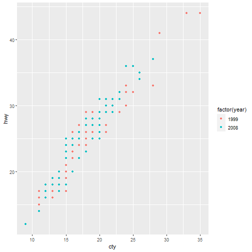

```r
#cty,hwy,year
ggplot(data=mpg,mapping=aes(x=cty,y=hwy))+       #数据
  geom_point()+                                  #几何图层
  aes(colour=factor(year))                       #视觉
```

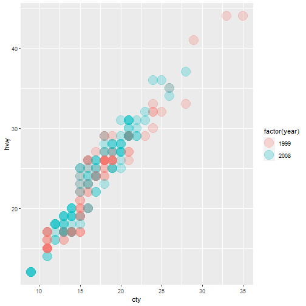

```r
#参数size调节点的大小,alpha表示不透明度
ggplot(data=mpg,aes(x=cty,y=hwy))+
  geom_point(size=I(7),alpha=0.25)+
  aes(colour=factor(year))
```

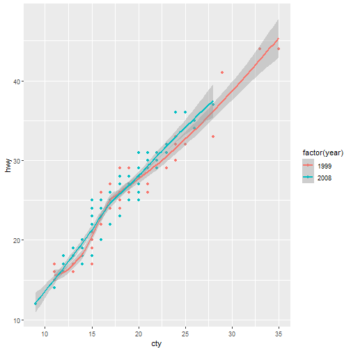

```r
#根据年份绘制出俩条拟合曲线以及置信区间
ggplot(data=mpg,aes(x=cty,y=hwy))+
  geom_point()+
  aes(colour=factor(year))+
  stat_smooth()
```

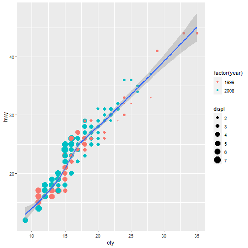

```r
#加入displ变量，映射到点的大小（一条拟合曲线以及置信区间）
ggplot(data=mpg,mapping =aes(x=cty,y=hwy))+
geom_point(aes(colour=factor(year),size=displ))+   #加入displ
  stat_smooth()
```